# Quick Top Ten Graph

Mike McLaughlin

March 5, 2017

# Quick Top Ten Graph - Time Savings

This application will replace a processes that is currently completed using Microsoft Excel.

- Each mornign a text file is automatically downloaded.
- Average file contains 95K lines of data.
- Data must be summarized and a table showing the top ten transactions by volume must be printed and made available to seneior managers.
- A graph is included at the request of one manager.

The process takes about 15 minutes to be completed by an experienced analyst. However, staff turn-over can result in errors and delays. This new process will take about 5 minutes and reduce errors.

# Requirements

- Text File with field names in the first row.
- File must contain numeric and text fields.
- Understanding of the data being processed - Otherwise, the graphs may not make sense.

The basic assumption is that a person creating these graphs understands the data and the purpose of the graph.

# Output Samples

This will generate a graph and a table.

#### Sample Graph and Table

```
## [1] "Graph - Tab 1"
```

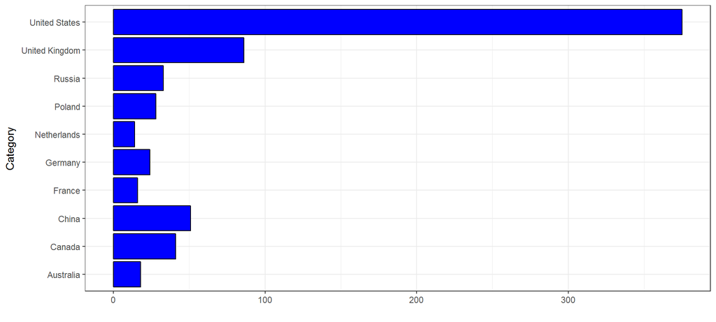

```
## [1] "Table - Tab 2"
```

```
##           COUNTRY Unique.Vistors
## 1   United States            375
## 2  United Kingdom             86
## 3           China             51
## 4          Canada             41
## 5          Russia             33
## 6          Poland             28
## 7         Germany             24
## 8       Australia             18
## 9          France             16
## 10    Netherlands             14
```

# Next Steps

- Add additonal calculations such as averages, factors and standard diviations.
- Review security concerns at this process resides on an external server.
- If security is a concern, review cost to build in-house system.
- Train additional staff on the process.